# What the SDID Literature Actually Does

Converted from PDF `Claude-SDIDLiteratureReview-2026-Note.pdf` · 8 pages · anchors: page `#pN`, block `#pN-bK`

Page 1

## L A Y O F F S · M E T H O D R E V I E W · 2 S E P T E M B E R 2 0 2 6 What the SDID literature actually does

#### Twelve marketing papers and three replication codebases, read for empirical

#### mechanics only. The short version: your architecture is the field's architecture, your

#### inference is ahead of the published bar, and you are missing four cheap things that

#### every one of these papers has.

12 PAPERS 3 REPLICATION REPOS READ LINE BY LINE 5 USE SDID AS THE PRIMARY ESTIMATOR

### I The consensus architecture

[output not shown]

NOTE: table converted from PDF layout to HTML text; cell boundaries are reconstructed. See PDF if exact alignment matters.

Page 2

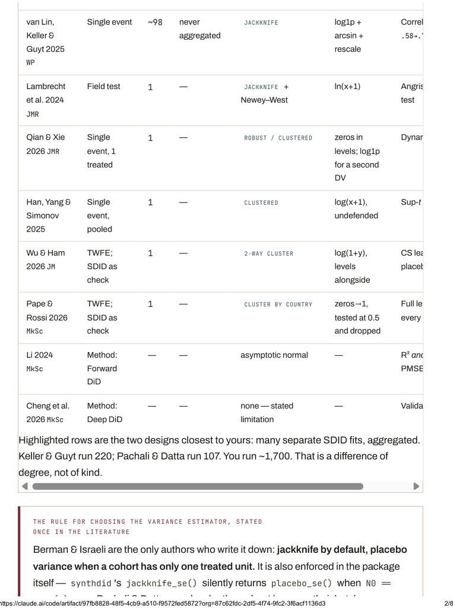

NOTE: complex table shown as an image of the PDF; the text below is a rough machine extraction and may be mis-aligned.

Page 3

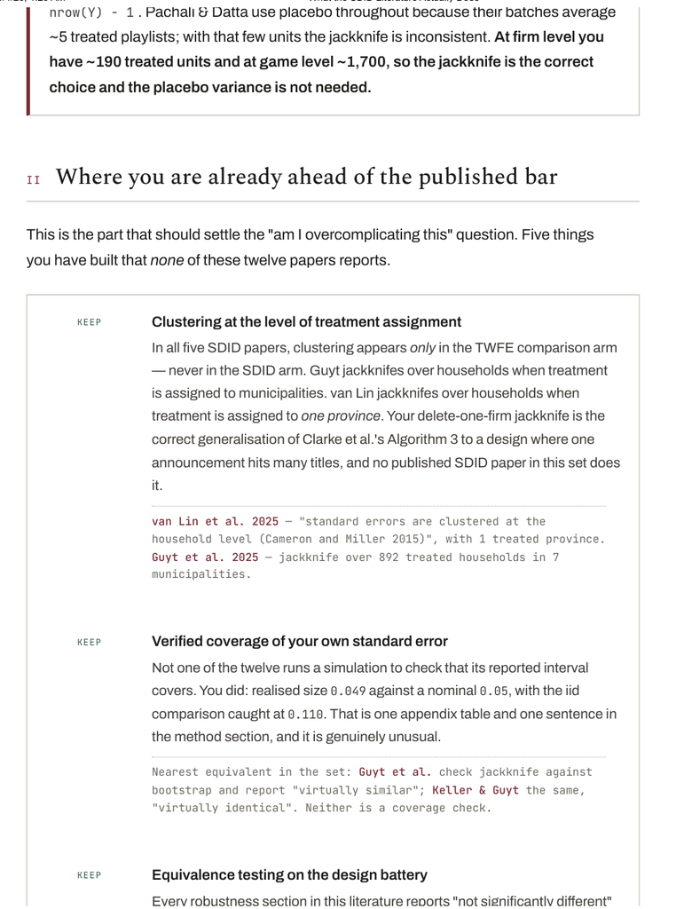

NOTE: figure/graphic rendered as an image from the PDF; its content is not machine-readable text. Caption (if any) follows as the next block.

**text found inside the figure**

nrow(Y) - 1 . Pachali & Datta use placebo throughout because their batches average

~5 treated playlists; with that few units the jackknife is inconsistent. At firm level you

have ~190 treated units and at game level ~1,700, so the jackknife is the correct

choice and the placebo variance is not needed.

II Where you are already ahead of the published bar

This is the part that should settle the "am I overcomplicating this" question. Five things

you have built that *none* of these twelve papers reports.

KEEP Clustering at the level of treatment assignment

In all five SDID papers, clustering appears *only* in the TWFE comparison arm

— never in the SDID arm. Guyt jackknifes over households when treatment

is assigned to municipalities. van Lin jackknifes over households when

treatment is assigned to *one province*. Your delete-one-firm jackknife is the

correct generalisation of Clarke et al.'s Algorithm 3 to a design where one

announcement hits many titles, and no published SDID paper in this set does

it.

van Lin et al. 2025 — "standard errors are clustered at the

household level (Cameron and Miller 2015)", with 1 treated province.

Guyt et al. 2025 — jackknife over 892 treated households in 7

municipalities.

KEEP Verified coverage of your own standard error

Not one of the twelve runs a simulation to check that its reported interval

covers. You did: realised size 0.049 against a nominal 0.05, with the iid

comparison caught at 0.110. That is one appendix table and one sentence in

the method section, and it is genuinely unusual.

Nearest equivalent in the set: Guyt et al. check jackknife against

bootstrap and report "virtually similar"; Keller & Guyt the same,

"virtually identical". Neither is a coverage check.

KEEP Equivalence testing on the design battery

Every robustness section in this literature reports "not significantly different"

Page 4

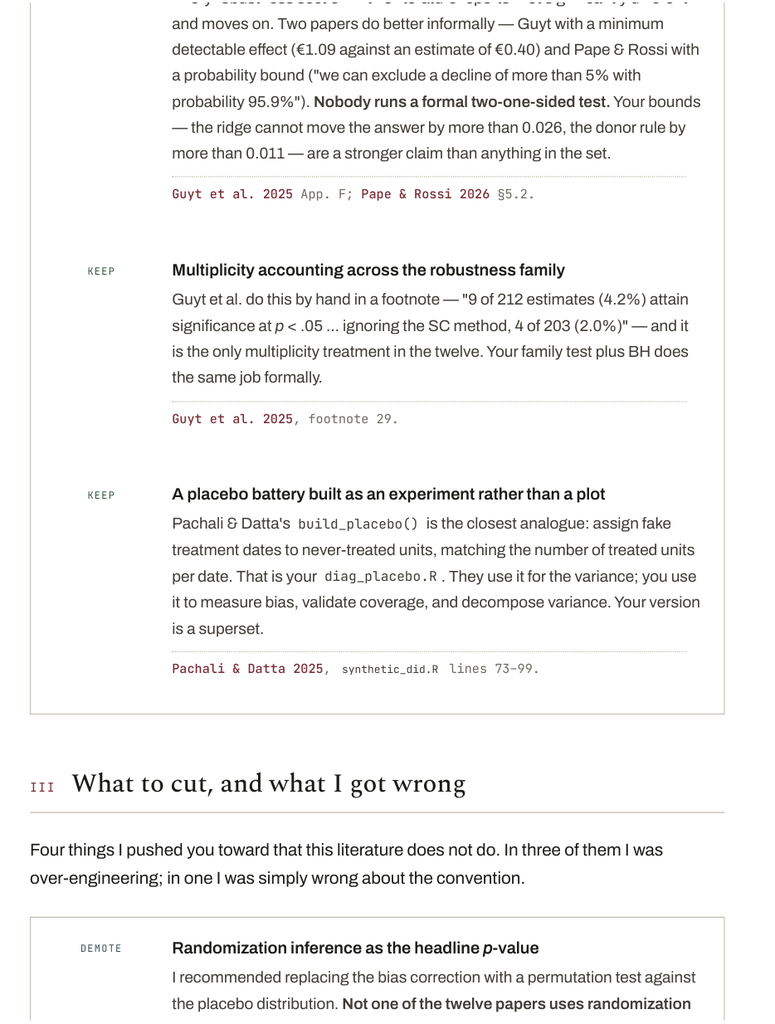

NOTE: figure/graphic rendered as an image from the PDF; its content is not machine-readable text. Caption (if any) follows as the next block.

**text found inside the figure**

and moves on. Two papers do better informally — Guyt with a minimum

detectable effect (€1.09 against an estimate of €0.40) and Pape & Rossi with

a probability bound ("we can exclude a decline of more than 5% with

probability 95.9%"). Nobody runs a formal two-one-sided test. Your bounds

— the ridge cannot move the answer by more than 0.026, the donor rule by

more than 0.011 — are a stronger claim than anything in the set.

Guyt et al. 2025 App. F; Pape & Rossi 2026 §5.2.

KEEP Multiplicity accounting across the robustness family

Guyt et al. do this by hand in a footnote — "9 of 212 estimates (4.2%) attain

significance at *p* < .05 … ignoring the SC method, 4 of 203 (2.0%)" — and it

is the only multiplicity treatment in the twelve. Your family test plus BH does

the same job formally.

Guyt et al. 2025, footnote 29.

KEEP A placebo battery built as an experiment rather than a plot

Pachali & Datta's build_placebo() is the closest analogue: assign fake

treatment dates to never-treated units, matching the number of treated units

per date. That is your diag_placebo.R . They use it for the variance; you use

it to measure bias, validate coverage, and decompose variance. Your version

is a superset.

Pachali & Datta 2025, synthetic_did.R lines 73–99.

III What to cut, and what I got wrong

Four things I pushed you toward that this literature does not do. In three of them I was

over-engineering; in one I was simply wrong about the convention.

DEMOTE Randomization inference as the headline p-value

I recommended replacing the bias correction with a permutation test against

the placebo distribution. Not one of the twelve papers uses randomization

Page 5

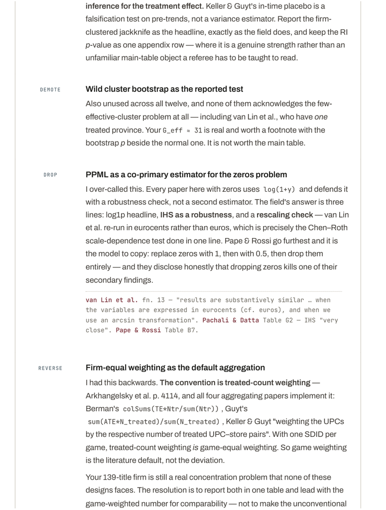

NOTE: figure/graphic rendered as an image from the PDF; its content is not machine-readable text. Caption (if any) follows as the next block.

**text found inside the figure**

inference for the treatment effect. Keller & Guyt's in-time placebo is a

falsification test on pre-trends, not a variance estimator. Report the firm-

clustered jackknife as the headline, exactly as the field does, and keep the RI

*p*-value as one appendix row — where it is a genuine strength rather than an

unfamiliar main-table object a referee has to be taught to read.

DEMOTE Wild cluster bootstrap as the reported test

Also unused across all twelve, and none of them acknowledges the few-

effective-cluster problem at all — including van Lin et al., who have *one*

treated province. Your G_eff ≈ 31 is real and worth a footnote with the

bootstrap *p* beside the normal one. It is not worth the main table.

DROP PPML as a co-primary estimator for the zeros problem

I over-called this. Every paper here with zeros uses log(1+y) and defends it

with a robustness check, not a second estimator. The field's answer is three

lines: log1p headline, IHS as a robustness, and a rescaling check — van Lin

et al. re-run in eurocents rather than euros, which is precisely the Chen–Roth

scale-dependence test done in one line. Pape & Rossi go furthest and it is

the model to copy: replace zeros with 1, then with 0.5, then drop them

entirely — and they disclose honestly that dropping zeros kills one of their

secondary findings.

van Lin et al. fn. 13 — "results are substantively similar … when

the variables are expressed in eurocents (cf. euros), and when we

use an arcsin transformation". Pachali & Datta Table G2 — IHS "very

close". Pape & Rossi Table B7.

REVERSE Firm-equal weighting as the default aggregation

I had this backwards. The convention is treated-count weighting —

Arkhangelsky et al. p. 4114, and all four aggregating papers implement it:

Berman's colSums(TE*Ntr/sum(Ntr)) , Guyt's

sum(ATE*N_treated)/sum(N_treated) , Keller & Guyt "weighting the UPCs

by the respective number of treated UPC–store pairs". With one SDID per

game, treated-count weighting *is* game-equal weighting. So game weighting

is the literature default, not the deviation.

Your 139-title firm is still a real concentration problem that none of these

designs faces. The resolution is to report both in one table and lead with the

game-weighted number for comparability — not to make the unconventional

Page 6

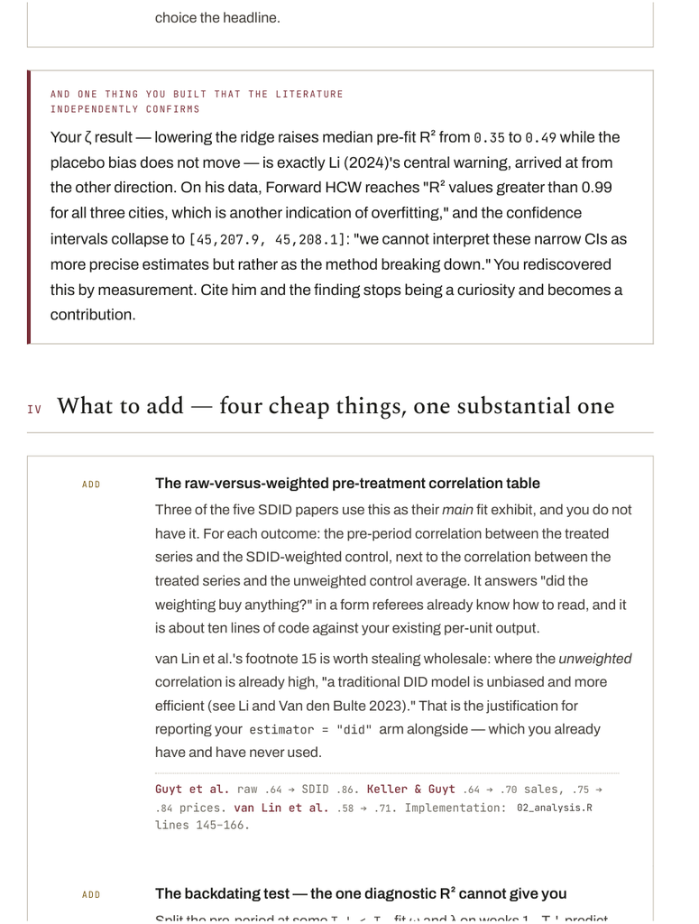

NOTE: figure/graphic rendered as an image from the PDF; its content is not machine-readable text. Caption (if any) follows as the next block.

**text found inside the figure**

choice the headline.

AND ONE THING YOU BUILT THAT THE LITERATURE

INDEPENDENTLY CONFIRMS

Your ζ result — lowering the ridge raises median pre-fit R² from 0.35 to 0.49 while the

placebo bias does not move — is exactly Li (2024)'s central warning, arrived at from

the other direction. On his data, Forward HCW reaches "R² values greater than 0.99

for all three cities, which is another indication of overfitting," and the confidence

intervals collapse to [45,207.9, 45,208.1]: "we cannot interpret these narrow CIs as

more precise estimates but rather as the method breaking down." You rediscovered

this by measurement. Cite him and the finding stops being a curiosity and becomes a

contribution.

IV What to add — four cheap things, one substantial one

ADD The raw-versus-weighted pre-treatment correlation table

Three of the five SDID papers use this as their *main* fit exhibit, and you do not

have it. For each outcome: the pre-period correlation between the treated

series and the SDID-weighted control, next to the correlation between the

treated series and the unweighted control average. It answers "did the

weighting buy anything?" in a form referees already know how to read, and it

is about ten lines of code against your existing per-unit output.

van Lin et al.'s footnote 15 is worth stealing wholesale: where the *unweighted*

correlation is already high, "a traditional DID model is unbiased and more

efficient (see Li and Van den Bulte 2023)." That is the justification for

reporting your estimator = "did" arm alongside — which you already

have and have never used.

Guyt et al. raw .64 → SDID .86. Keller & Guyt .64 → .70 sales, .75 →

.84 prices. van Lin et al. .58 → .71. Implementation: 02_analysis.R

lines 145–166.

ADD The backdating test — the one diagnostic R² cannot give you

Page 7

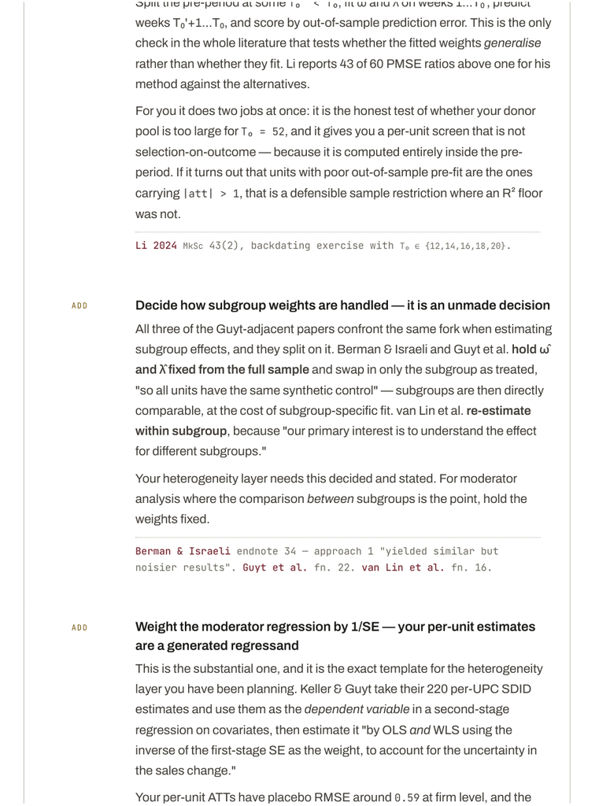

NOTE: figure/graphic rendered as an image from the PDF; its content is not machine-readable text. Caption (if any) follows as the next block.

**text found inside the figure**

check in the whole literature that tests whether the fitted weights *generalise*

rather than whether they fit. Li reports 43 of 60 PMSE ratios above one for his

method against the alternatives.

For you it does two jobs at once: it is the honest test of whether your donor

pool is too large for T₀ = 52, and it gives you a per-unit screen that is not

selection-on-outcome — because it is computed entirely inside the pre-

period. If it turns out that units with poor out-of-sample pre-fit are the ones

carrying |att| > 1, that is a defensible sample restriction where an R² floor

was not.

Li 2024 MkSc 43(2), backdating exercise with T₀ ∈ {12,14,16,18,20}.

ADD Decide how subgroup weights are handled — it is an unmade decision

All three of the Guyt-adjacent papers confront the same fork when estimating

subgroup effects, and they split on it. Berman & Israeli and Guyt et al. hold **ω̂**

and **λ̂** fixed from the full sample and swap in only the subgroup as treated,

"so all units have the same synthetic control" — subgroups are then directly

comparable, at the cost of subgroup-specific fit. van Lin et al. re-estimate

within subgroup, because "our primary interest is to understand the effect

for different subgroups."

Your heterogeneity layer needs this decided and stated. For moderator

analysis where the comparison *between* subgroups is the point, hold the

weights fixed.

Berman & Israeli endnote 34 — approach 1 "yielded similar but

noisier results". Guyt et al. fn. 22. van Lin et al. fn. 16.

ADD Weight the moderator regression by 1/SE — your per-unit estimates are a generated regressand

This is the substantial one, and it is the exact template for the heterogeneity

layer you have been planning. Keller & Guyt take their 220 per-UPC SDID

estimates and use them as the *dependent variable* in a second-stage

regression on covariates, then estimate it "by OLS *and* WLS using the

inverse of the first-stage SE as the weight, to account for the uncertainty in

the sales change."

Your per-unit ATTs have placebo RMSE around 0.59 at firm level, and the

Page 8

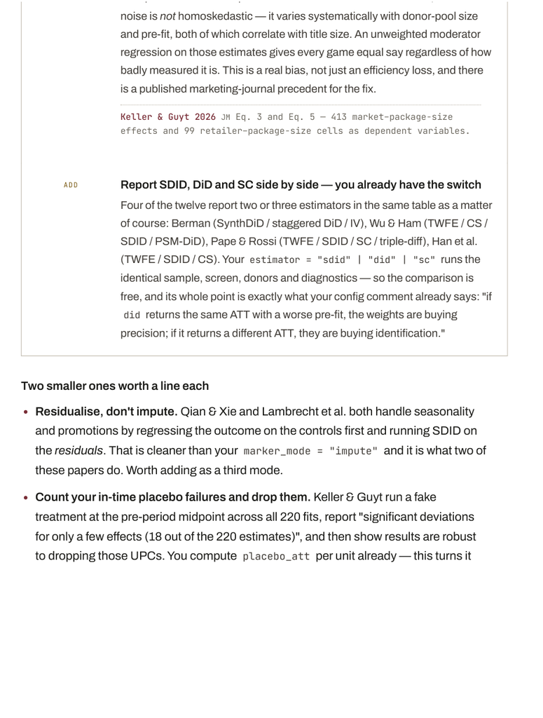

NOTE: figure/graphic rendered as an image from the PDF; its content is not machine-readable text. Caption (if any) follows as the next block.

**text found inside the figure**

noise is *not* homoskedastic — it varies systematically with donor-pool size

and pre-fit, both of which correlate with title size. An unweighted moderator

regression on those estimates gives every game equal say regardless of how

badly measured it is. This is a real bias, not just an efficiency loss, and there

is a published marketing-journal precedent for the fix.

Keller & Guyt 2026 JM Eq. 3 and Eq. 5 — 413 market–package-size

effects and 99 retailer–package-size cells as dependent variables.

ADD Report SDID, DiD and SC side by side — you already have the switch

SDID / PSM-DiD), Pape & Rossi (TWFE / SDID / SC / triple-diff), Han et al.

(TWFE / SDID / CS). Your estimator = "sdid" | "did" | "sc" runs the

identical sample, screen, donors and diagnostics — so the comparison is

free, and its whole point is exactly what your config comment already says: "if

did returns the same ATT with a worse pre-fit, the weights are buying

precision; if it returns a different ATT, they are buying identification."

Two smaller ones worth a line each

Residualise, don't impute. Qian & Xie and Lambrecht et al. both handle seasonality

and promotions by regressing the outcome on the controls first and running SDID on

the *residuals*. That is cleaner than your marker_mode = "impute" and it is what two of

these papers do. Worth adding as a third mode.

Count your in-time placebo failures and drop them. Keller & Guyt run a fake

treatment at the pre-period midpoint across all 220 fits, report "significant deviations